title: “TallerEDO”

author: “Pedro Escobar, Valentina Escobar”

date: “26 de octubre de 2018”

[output not shown]

## Taller EDO Metodos: Euler y Runge Kutta

Cargando librerías:

```r
library(phaseR)

library(pracma)
```

Primer Punto: Usando el método de Euler (en R) y 20 intervalos iguales y t variando de 0 a 200 segundos, resuelva numéricamente la ecuación, si el cuerpo es un cubo de lados de longitud 1m y masa igual a 1Kg. Asuma, que T0 = 180K, Te = 200K, g = 0.5 y C = 100J/(Kg/K). Hacer una representación gráfica del resultado.

```r
metodoEuler <- function(f, h, xi, yi, xf)

{

  N = (xf - xi) / h

  x = y = numeric(N+1)

  x[1] = xi;

  y[1] = yi;

  i = 1

  while (i <= N)

  {

    x[i+1] = x[i]+h

    y[i+1] = y[i]+(h*f(x[i],y[i]))

    i = i+1

  }

  return (data.frame(X = x, Y = y))

}





f <- function(x, y) {-1.68*10^(-9)*(x^4)+2.6880}



e1 = metodoEuler(f, 10, 0, 180, 200)

print(e1)
```

```
##      X        Y
## 1    0 180.0000
## 2   10 206.8800
## 3   20 233.7598
## 4   30 260.6371
## 5   40 287.5035
## 6   50 314.3405
## 7   60 341.1155
## 8   70 367.7778
## 9   80 394.2544
## 10  90 420.4463
## 11 100 446.2241
## 12 110 471.4241
## 13 120 495.8444
## 14 130 519.2407
## 15 140 541.3225
## 16 150 561.7486
## 17 160 580.1236
## 18 170 595.9935
## 19 180 608.8420
## 20 190 618.0860
## 21 200 623.0721
```

```r
e1[nrow(e1),]
```

|  | X | Y |
| --- | --- | --- |
| 21 | 200 | 623.0721 |

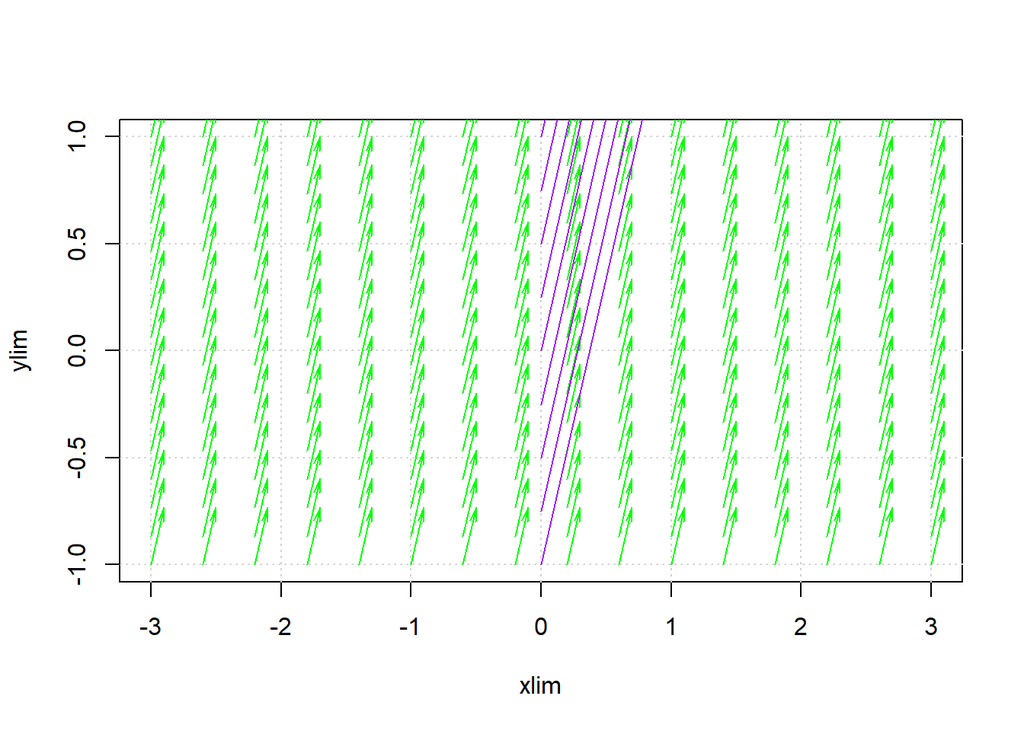

```r
xx <- c(-3, 3); yy <- c(-1, 1)

vectorfield(f, xx, yy, scale = 0.1)

for (xs in seq(-1, 1, by = 0.25))

{

  sol <- rk4(f, 0, 200, xs, 100)

  lines(sol$x, sol$y, col="purple")

}
```

Segundo Punto:

```
## y  1.215
## x  0.1  y  1.461025
## x  0.2  y  1.739233
## x  0.3  y  2.050902
## x  0.4  y  2.397447
## x  0.5  y  2.780429
## x  0.6  y  3.201574
## x  0.7  y  3.662789
## x  0.8  y  4.166182
## x  0.9  y  4.714081
## x  1  y  5.309059
## x  1.1  y  5.953961
## x  1.2  y  6.651926
## x  1.3  y  7.406429
## x  1.4  y  8.221304
## x  1.5  y  9.100791
## x  1.6  y  10.04957
## x  1.7  y  11.07283
## x  1.8  y  12.17628
## x  1.9  y  13.36623
## x  2
```

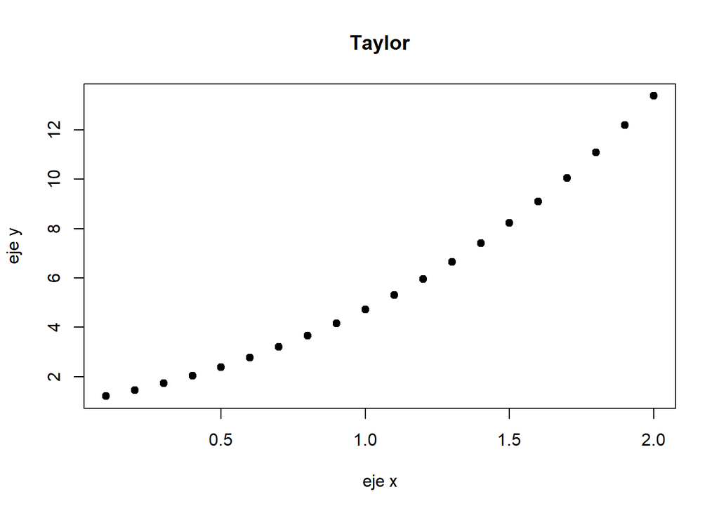

```r
taylor = function(f,df,x,y,h,m){

a=c()
b=c()
u=c()
v=c()
for (i in 1:m){
  y=y+h*f(x,y)+h**2/2*df(x,y)
  x=x+h
  u[i]=u+x
  v[i]=v+y
  cat("y ",round(y,6)," ","\n")
  cat("x ",round(x,6)," ")
  a[i]=y
  b[i]=x

}
plot(b,a, pch=19, type="p", xlab= "eje x", ylab= "eje y", col="black", main="Taylor")



}

f = function(x,y){

return (x-x**2+y+1)
}

df = function(x,y){

  return (y-x**2-x+2)
}


taylor(f,df,0,1,0.1,20)
```

Error de truncamiento O(h^3)=O(0.001)

y(0.1) = 1.2152 y(0.2) = 1.4614

Solución con el método

x = 0.1, y = 1.215 x = 0.2, y = 1.461025  
x = 0.3, y = 1.739233

Tercer Punto: Obtenga 20 puntos de la solución de la ecuación, utilizando el método de Euler (los tres primeros términos)con h=0.1

```r
euler1 = function(init, xis ,func) {

  n = length(xis)

  h = xis[2] - xis[1]

  v.num = vector(length = n)

  v.num[1] = init

  for (j in 1:(n-1)) {

    v.num [j+1] = v.num [j] +

      h*func(xis[j], v.num[j]) }

  v.num}

# --- Pruebas

f = function(x,y) x+y+1-x^2

xis= seq(0,2,0.1)

euler1(1, xis, f)
```

```
##  [1]  1.000000  1.200000  1.429000  1.687900  1.977690  2.299459  2.654405
##  [8]  3.043845  3.469230  3.932153  4.434368  4.977805  5.564586  6.197044
## [15]  6.877749  7.609523  8.395476  9.239023 10.143926 11.114318 12.154750
```

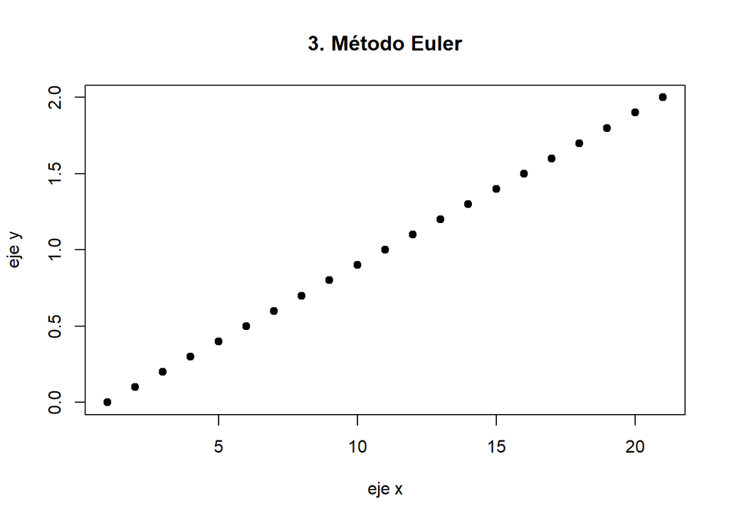

```r
plot(xis, pch=19, type="p", xlab= "eje x", ylab= "eje y", col="black", main="3. Método Euler")
```

Cuarto punto: Implemente en R el algoritmo y aplíquelo para resolver la ecuación anterior - ver algoritmo del enunciado-

```
## ----Resultados----
## [ 1 ]  1.2145
## [ 2 ]  1.459973
## [ 3 ]  1.73757
## [ 4 ]  2.048564
## [ 5 ]  2.394364
## [ 6 ]  2.776522
## [ 7 ]  3.196757
## [ 8 ]  3.656966
## [ 9 ]  4.159248
## [ 10 ]  4.705919
## [ 11 ]  5.29954
## [ 12 ]  5.942942
## [ 13 ]  6.639251
## [ 14 ]  7.391922
## [ 15 ]  8.204774
## [ 16 ]  9.082025
## [ 17 ]  10.02834
## [ 18 ]  11.04886
## [ 19 ]  12.14929
## [ 20 ]  13.33592
```

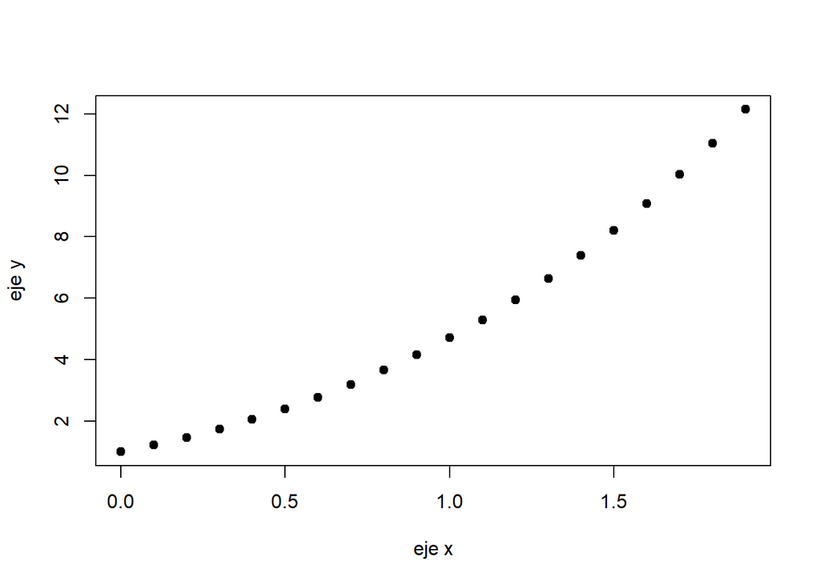

```r
heun = function(f,x,y,h,m){
  cat("----Resultados----\n")
  u=c()
  v=c()
  xes=c()
  yes=c()
  for (i in 1:m){
    k1=h*f(x,y)
    k2=h*f(x+h,y+k1)
    xes[i]=x
    yes[i]=y
    y=y+0.5*(k1+k2)
    x=x+h
    u[i]=u+x
    v[i]=v+y
    cat("[",i,"] ",y, "\n")
  }
  plot(xes, yes, pch=19, type="p", xlab= "eje x", ylab= "eje y", col="black")

}

f = function(x,y){

  return (x-x**2+y+1)
}
heun(f,0,1,0.1,20)
```

Quinto Punto: Utilizar la siguiente variación en el método de Euler, para resolver una ecuación diferencial ordinaria de primer orden, la cual calcula el promedio de las pendientes en cada paso

-Ver ecuación del enunciado-

-Ver ecuación del enunciado-

```
## 1     0
## 1.2095     0.1
## 1.448     0.2
## 1.7162     0.3
## 2.0154     0.4
## 2.3464     0.5
## 2.7105     0.6
## 3.1091     0.7
## 3.5435     0.8
## 4.0154     0.9
```

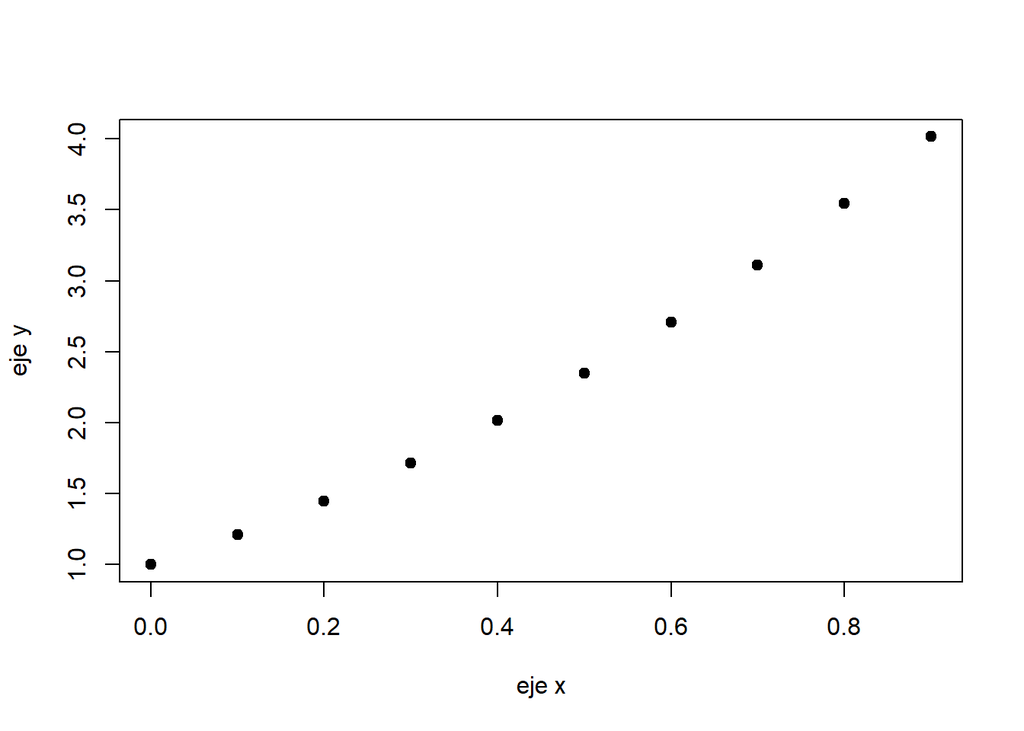

```r
euler1 = function(xi, yi ,func, n) {
  h=0.1
  xes=c()
  yes=c()
  for( i in 1:10){
    k1=(f(xi,yi))
    k2=(f(xi+h, yi+h))
    yes[i]=yi
    xes[i]=xi
    cat(round(yi,4), "   ", round(xi,4), "\n")
    yi=yi+(h/2)*(k1+k2)
    xi= xi+h
  }
  plot(xes,yes, pch=19, type="p", xlab= "eje x", ylab= "eje y", col="black")
}

# --- Pruebas

f = function(x,y) x+y+1-x^2

euler1(0, 1, f, 10)
```

Séptimo punto: Obtenga 10 puntos de la solución con h=0.1, grafíquela y compárela con el método de Euler:

```r
f<-function(fcn,x,y){

  return(eval(fcn))

}



# Solo para prueba con dy=x+y, y(0)=1

obtenerErrorAbsoluto<-function(x,y){

  solucion=exp(x)*((-x*exp(-x))-exp(-x)+2)

  return(abs(y-solucion))

}



graficarCampoPendiente<-function(x0, xn, y0, yn, fcn, numpendientes, metodo){

  apma1 <- function(t, y, parameters){

    a <- parameters[1]

    dy <- a*(f(fcn, t, y))

    list(dy)

  }

  apma1.flowField <- flowField(apma1, x = c(x0, xn),

                               y   = c(y0, yn), parameters = c(1),

                               points = numpendientes, system = "one.dim",

                               add = FALSE, xlab = "x", ylab = "y",

                               main = metodo)

  grid()

}



graficarSolucionNumerica<-function (x, y){

  points (x, y, pch=20, col="blue")

  for (i in 2:length(x)){

    segments(x[i-1], y[i-1], x[i], y[i], col="red")

  }

}



erreka4<-function(dy, ti, tf, y0, h, graficar=TRUE, numpendientes=10){

  t<-seq(ti, tf, h)

  y<-c(y0)

  cat("x    |y         |k1        |k2        |k3        |k4       |error absoluto\n")

  for(i in 2:length(t)){

    k1=h*f(dy, t[i-1], y[i-1])

    k2=h*f(dy, t[i-1]+h/2, y[i-1]+k1*(0.5))

    k3=h*f(dy, t[i-1]+h/2, y[i-1]+k2*(0.5))

    k4=h*f(dy, t[i-1]+h, y[i-1]+k3)

    y<-c(y, y[i-1]+1/6*(k1+2*k2+2*k3+k4))

    cat(t[i-1]," | ", y[i-1]," | ",k1," | ",k2," | ",k3," | ",k4," | ",obtenerErrorAbsoluto(t[i-1],y[i-1]),"\n")

  }

  if (graficar){

    graficarCampoPendiente(min(t), max(t), min(y), max(y), dy, numpendientes, "RK4")

    graficarSolucionNumerica(t, y)

  }

  rta<-list(w=y, t=t)

}



erreka3<-function(dy, ti, tf, y0, h, graficar=TRUE, numpendientes=10){

  t<-seq(ti, tf, h)

  y<-c(y0)

  cat("x    |y         |k1         |k2        |k3       |error absoluto\n")

  for(i in 2:length(t)){

    k1=h*f(dy, t[i-1], y[i-1])

    k2=h*f(dy, t[i-1]+h/2, y[i-1]+k1*(0.5))

    k3=h*f(dy, t[i-1]+h, y[i-1]-k1+2*k2)

    y<-c(y, y[i-1]+1/6*(k1+4*k2+k3))

    cat(t[i-1]," | ", y[i-1]," | ",k1," | ",k2," | ",k3," | ",obtenerErrorAbsoluto(t[i-1],y[i-1]),"\n")

  }

  if (graficar){

    graficarCampoPendiente(min(t), max(t), min(y), max(y), dy, numpendientes, "RK3")

    graficarSolucionNumerica(t, y)

  }

  rta<-list(w=y, t=t)

}

r<-erreka4(expression(x+y+1-x^2), 0, 1, 1, 0.1)
```

```
## x    |y         |k1        |k2        |k3        |k4       |error absoluto
## 0  |  1  |  0.2  |  0.21475  |  0.2154875  |  0.2305488  |  0
## 0.1  |  1.215171  |  0.2305171  |  0.2457929  |  0.2465567  |  0.2621727  |  0.1048288
## 0.2  |  1.461402  |  0.2621402  |  0.2779972  |  0.2787901  |  0.2950192  |  0.2185966
## 0.3  |  1.739858  |  0.2949858  |  0.3114851  |  0.31231  |  0.3292168  |  0.3401402
## 0.4  |  2.051823  |  0.3291823  |  0.3463914  |  0.3472519  |  0.3649075  |  0.4681739
## 0.5  |  2.398719  |  0.3648719  |  0.3828655  |  0.3837652  |  0.4022485  |  0.6012768
## 0.6  |  2.782116  |  0.4022116  |  0.4210722  |  0.4220152  |  0.4414132  |  0.7378787
## 0.7  |  3.20375  |  0.441375  |  0.4611937  |  0.4621846  |  0.4825934  |  0.8762442
## 0.8  |  3.665537  |  0.4825537  |  0.5034314  |  0.5044753  |  0.5260012  |  1.014455
## 0.9  |  4.169599  |  0.5259599  |  0.5480078  |  0.5491102  |  0.5718709  |  1.150392
```

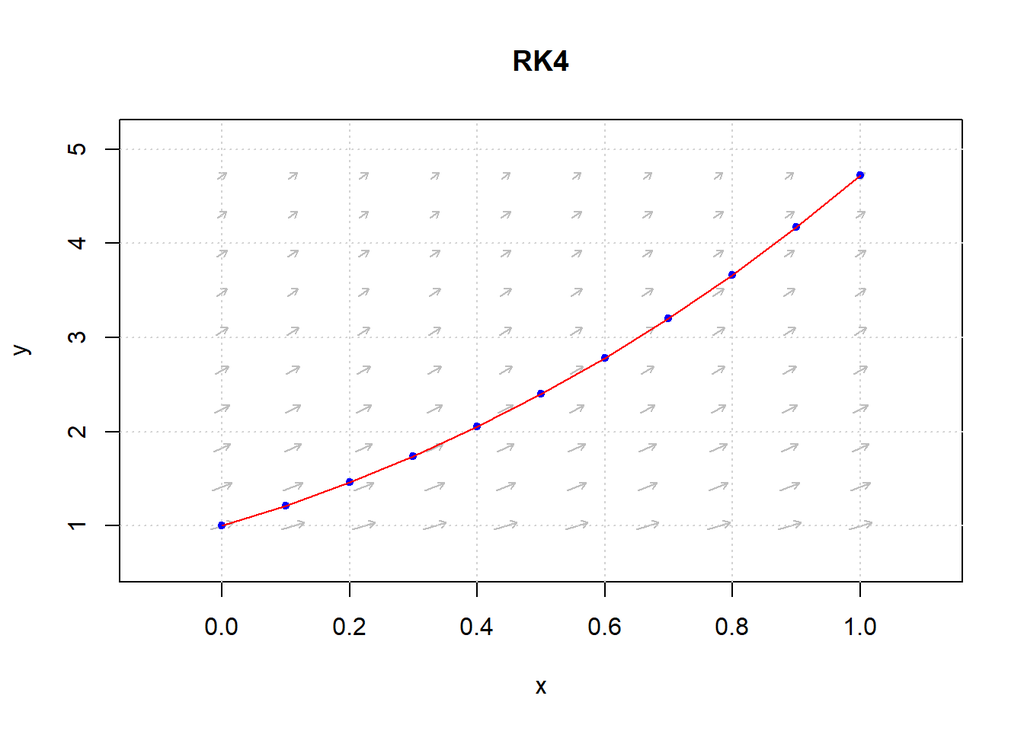

```r
r2<-erreka3(expression(x+y+1-x^2), 0, 1, 1, 0.1)
```

```
## x    |y         |k1         |k2        |k3       |error absoluto
## 0  |  1  |  0.2  |  0.21475  |  0.23195  |  0
## 0.1  |  1.215158  |  0.2305158  |  0.2457916  |  0.2636226  |  0.1048165
## 0.2  |  1.461376  |  0.2621376  |  0.2779945  |  0.2965227  |  0.2185703
## 0.3  |  1.739816  |  0.2949816  |  0.3114806  |  0.3307795  |  0.3400979
## 0.4  |  2.051763  |  0.3291763  |  0.3463851  |  0.3665357  |  0.4681134
## 0.5  |  2.398638  |  0.3648638  |  0.382857  |  0.4039488  |  0.6011956
## 0.6  |  2.782012  |  0.4022012  |  0.4210612  |  0.4431933  |  0.737774
## 0.7  |  3.203618  |  0.4413618  |  0.4611799  |  0.4844616  |  0.8761127
## 0.8  |  3.665375  |  0.4825375  |  0.5034144  |  0.5279667  |  1.014293
## 0.9  |  4.169402  |  0.5259402  |  0.5479872  |  0.5739437  |  1.150196
```

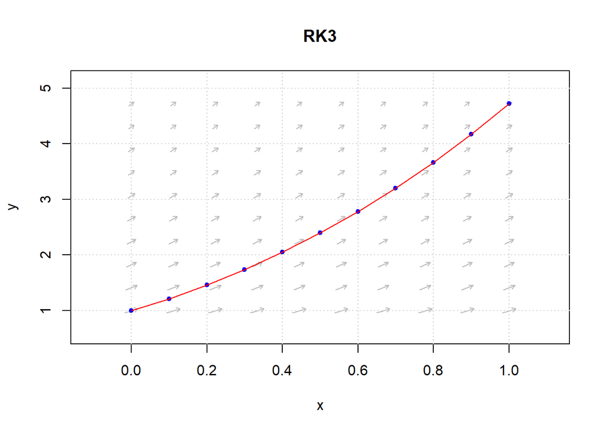

Ahora el método de Euler:

```r
metodoEuler <- function(f, h, xi, yi, xf)

{

  N = (xf - xi) / h

  x = y = numeric(N+1)

  x[1] = xi;

  y[1] = yi;

  i = 1

  while (i <= N)

  {

    x[i+1] = x[i]+h

    y[i+1] = y[i]+(h*f(x[i],y[i]))

    i = i+1

  }

  return (data.frame(X = x, Y = y))

}



f <- function(x, y) {x-y}

dy<- function(x,y){x+y+1-x^2}



e1 = metodoEuler(dy, 0.1, 0, 1, 1)



e1[nrow(e1),]
```

|  | X | Y |
| --- | --- | --- |
| 11 | 1 | 4.434368 |

```r
e1
```

| X | Y |
| --- | --- |
| 0.0 | 1.000000 |
| 0.1 | 1.200000 |
| 0.2 | 1.429000 |
| 0.3 | 1.687900 |
| 0.4 | 1.977690 |
| 0.5 | 2.299459 |
| 0.6 | 2.654405 |
| 0.7 | 3.043845 |
| 0.8 | 3.469230 |
| 0.9 | 3.932153 |

[output cut: 1 more lines]

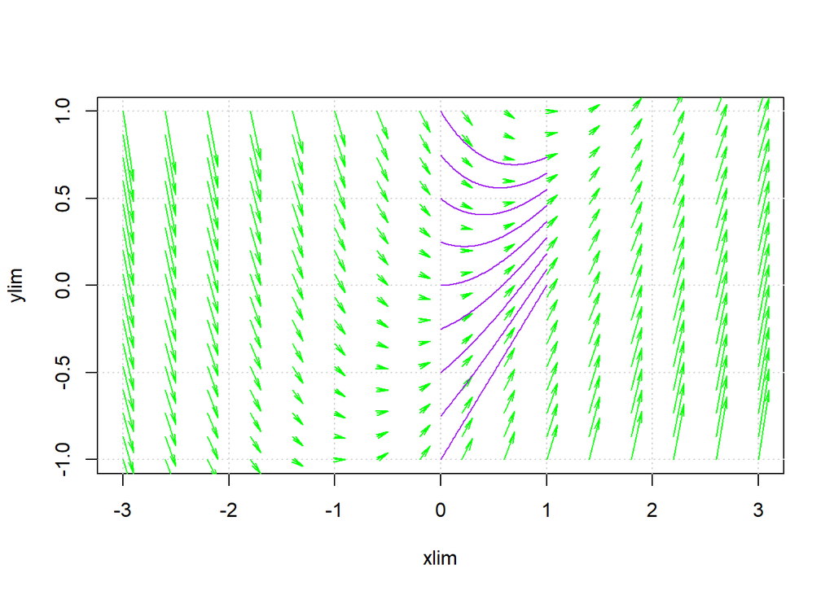

```r
xx <- c(-3, 3); yy <- c(-1, 1)

vectorfield(f, xx, yy, scale = 0.1)

for (xs in seq(-1, 1, by = 0.25))

{

  sol <- rk4(f, 0, 1, xs, 100)

  lines(sol$x, sol$y, col="purple")

}
```